# Outlier and Anomaly Detection

Sasha Gryshchenko

## Data Exploration

We begin with loading the data and exploring the patterns seen in the variables. First, we wish to understand what the variables are and infer whether we’ll be needing them for the future analyses.

```r
flights <- read.csv("~/Documents/GitHub/DataAnalysis-Sasha-Ced/Flights1_2019_1.csv")
summary(flights)
```

```
##       YEAR       DAY_OF_WEEK      FL_DATE          ORIGIN_AIRPORT_ID
##  Min.   :2019   Min.   :1.000   Length:583985      Min.   :10135
##  1st Qu.:2019   1st Qu.:2.000   Class :character   1st Qu.:11292
##  Median :2019   Median :4.000   Mode  :character   Median :12889
##  Mean   :2019   Mean   :3.836                      Mean   :12660
##  3rd Qu.:2019   3rd Qu.:5.000                      3rd Qu.:13931
##  Max.   :2019   Max.   :7.000                      Max.   :16218
##
##  ORIGIN_AIRPORT_SEQ_ID ORIGIN_CITY_MARKET_ID ORIGIN_CITY_NAME   DEST_AIRPORT_ID
##  Min.   :1013505       Min.   :30070         Length:583985      Min.   :10135
##  1st Qu.:1129202       1st Qu.:30721         Class :character   1st Qu.:11292
##  Median :1288903       Median :31453         Mode  :character   Median :12889
##  Mean   :1265974       Mean   :31753                            Mean   :12659
##  3rd Qu.:1393102       3rd Qu.:32467                            3rd Qu.:13931
##  Max.   :1621802       Max.   :35991                            Max.   :16218
##
##  DEST_AIRPORT_SEQ_ID DEST_CITY_MARKET_ID DEST_CITY_NAME     DEST_STATE_ABR
##  Min.   :1013505     Min.   :30070       Length:583985      Length:583985
##  1st Qu.:1129202     1st Qu.:30721       Class :character   Class :character
##  Median :1288903     Median :31453       Mode  :character   Mode  :character
##  Mean   :1265951     Mean   :31753
##  3rd Qu.:1393102     3rd Qu.:32467
##  Max.   :1621802     Max.   :35991
##
##    DEP_DELAY           ARR_TIME       ARR_DELAY        ARR_DELAY_NEW
##  Min.   : -47.000   Min.   :   1    Min.   : -85.000   Min.   :   0.00
##  1st Qu.:  -6.000   1st Qu.:1104    1st Qu.: -16.000   1st Qu.:   0.00
##  Median :  -3.000   Median :1517    Median :  -7.000   Median :   0.00
##  Mean   :   9.766   Mean   :1484    Mean   :   4.258   Mean   :  13.65
##  3rd Qu.:   5.000   3rd Qu.:1919    3rd Qu.:   7.000   3rd Qu.:   7.00
##  Max.   :1651.000   Max.   :2400    Max.   :1638.000   Max.   :1638.00
##  NA's   :16355      NA's   :17061   NA's   :18022      NA's   :18022
##    ARR_DEL15        X
##  Min.   :0.000   Mode:logical
##  1st Qu.:0.000   NA's:583985
##  Median :0.000
##  Mean   :0.186
##  3rd Qu.:0.000
##  Max.   :1.000
##  NA's   :18022
```

Looks like there are a lot of variable roughly describing the same things - like those relating to location (airport IDs and city names), so we won’t be needing both types. Furthermore, there are “corrected” versions of the arrival times - we will keep the original delays (the “new” arrival delay seems to have replaced negative values with zeroes) and arr_del15 - it may come in handy later. The section below further explands on the decisions made to keep/drop certain variables.

## Data Dictionary

Flights, or RITA (Reporting Carrier On-Time Performance), Data Dictionary

| Name | Definition | Data Type | Domain | Required |
| --- | --- | --- | --- | --- |
| YEAR | year of flight | numeric | {2019} | no |
| DAY_OF_WEEK | day of week for the flight | numeric | $$1, 7$$ | yes |
| FL_DATE | date of flight | character | $$2019-01-01, 2019-01-31$$ | yes |
| ORIGIN_AIRPORT_ID | airport ID at the origin | numeric | $$10,135, 16,218$$ | no |
| ORIGIN_AIRPORT_SEQ_ID | airport ID at the origin (at the sequential level) | numeric | $$1,013,505, 1,621,802$$ | no |
| ORIGIN_CITY_MARKET_ID | identification number assigned to identify a city market at the origin | numeric | $$30,070, 35,991$$ | no |
| ORIGIN_CITY_NAME | US city and state name at the origin | character | *340 unique cities | yes |
| DEST_AIRPORT_ID | airport ID at the destination | numeric | $$10,135, 16,218$$ | no |
| DEST_AIRPORT_SEQ_ID | airport ID at the destination (at the sequential level) | numeric | $$1,013,505, 1,621,802$$ | no |
| DEST_CITY_MARKET_ID | identification number assigned to identify a city market at the destination | numeric | $$30,070, 35,991$$ | no |
| DEST_CITY_NAME | US city and state name at the destination | character | *340 unique cities | yes |
| DEST_STATE_ABR | abbreviated name of state at the destination | character | *52 unique names | yes |
| DEP_DELAY | delay of departure in minutes | numeric | $$-47, 1,651$$ | yes |
| ARR_TIME | time of arrival | numeric | $$1, 2,400$$ | no |
| ARR_DELAY | delay of arrival in minutes | numeric | $$-85, 1,638$$ | yes |
| ARR_DELAY_NEW | adjusted delay of arrival in minutes | numeric | $$0, 1,638$$ | yes |
| ARR_DEL15 | unknown | numeric | {0, 1} | yes |
| X | unknown | uknown | none | no |

For the variables **origin_city_name** and **dest_city_name**, we can separate the state name after the city name into its own variable. Also, we will drop variables that we previously stated were considered to be unlikely to contribute to the outlier detection.

We can visualize how many flights occurred on any given day, of which there were 31 (the month of January in 2019), and see if there are any visible differences in the data. We see that the majority of the number of flights were above 18,000, with 5 observations below that threshold. With the boxplot, we see that there are three outliers (using Tukey’s boxplot test). These occur on the 12th, 19th, and 26th of the month.

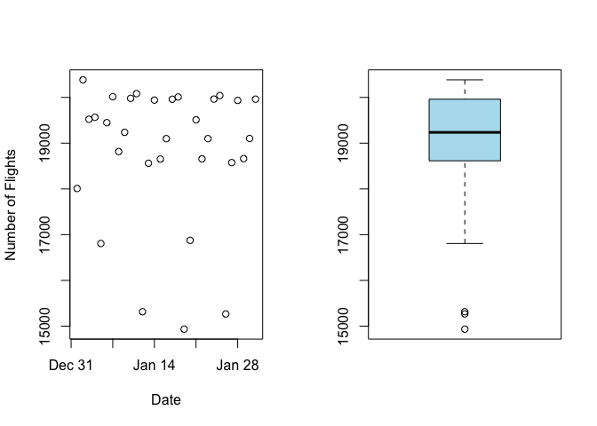

Number of Flights Exploration: Month

Some of the destination cities include two city names - presumably because the persons travelling are flying to an airport closest to their actual destination (perhaps there isn’t an airport at the final destination). For those cases, we will only keep the name of the city that has an airport for simplicity. This may have some drawbacks - airports located on the edge of the state may cause some confusion (e.g., Dulles airport is located in Virginia, but people often arrive there when travelling to Washington, D.C.) or mislabeling the actual destination. We will carry on with the changes as we want to see the name of the city, rather than the location of the airport.

We can now study the number of flights on any particular day of the week.

## Data Exploration

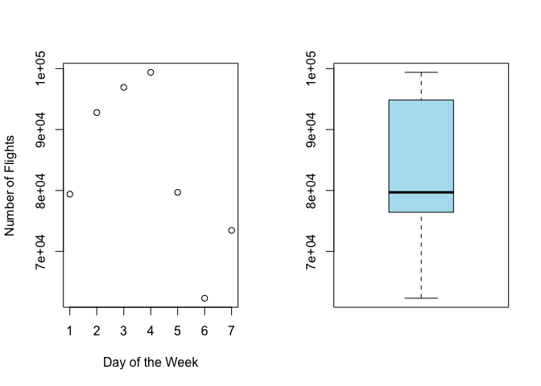

Number of Flights Exploration: Weekdays

Assuming that 1 corresponds to a Monday (we checked that January 1, 2019 is a Tuesday and corresponds to a 2 in the data), we notice that the number of flights is lower on day 6, which is a Saturday, than it is on the rest of the days of the week.

In the boxplot, we actually see that there are no outliers - so perhaps it is the case that less people fly to and from the cities in the dataset on a Saturday. This may or may not be true, but we will leave this matter alone for now and explore the rest of the data.

Next, we can take a look at how many flights departed from each city to notice if there are any blank spaces with very few odd flights or if they are spread across the country.

```r
originflight <- aggregate(flights$VALUE, by=list(flights$ORIGIN_STATE_ABR,flights$ORIGIN_CITY_NAME), sum)
colnames(originflight) <- c("state","city","FlightNum")

destflight <- aggregate(flights$VALUE, by=list(flights$DEST_STATE_ABR,flights$DEST_CITY_NAME), sum)
colnames(destflight) <- c("state","city","FlightNum")
```

```r
uscities <- read.csv("~/Documents/GitHub/DataAnalysis-Sasha-Ced/uscities.csv")
originlatlon <- merge(x=subset(uscities,select=c("city","state_name","lat","lng","state_id")),y=originflight,
      by.x=c("city","state_id"),by.y=c("city","state"))
```

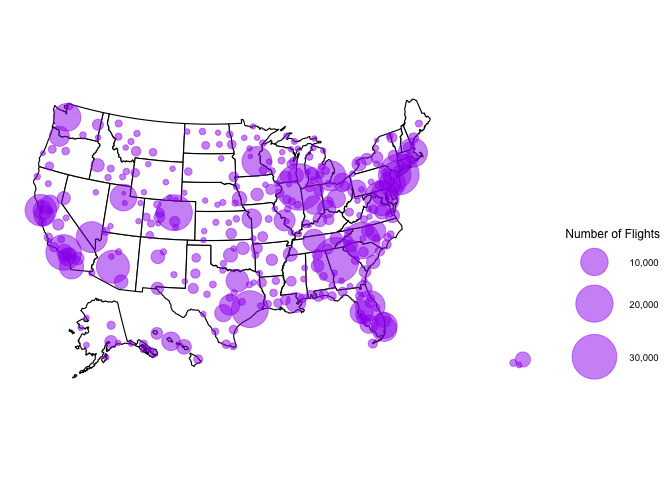

Number of Flights by City: Departures

In using the maps to help us understand the data, we notice that the origin/destination include Puerto Rico (the actual island outline is not shown on either map) as well as parts of the USA. For the origin of flights, we see that the majority depart from the East Coast, as well as a lot of departures from CA, TX, and CO.

```r
destlatlon <- merge(x=subset(uscities,select=c("city","state_name","lat","lng","state_id")),y=destflight,
      by.x=c("city","state_id"),by.y=c("city","state"))
```

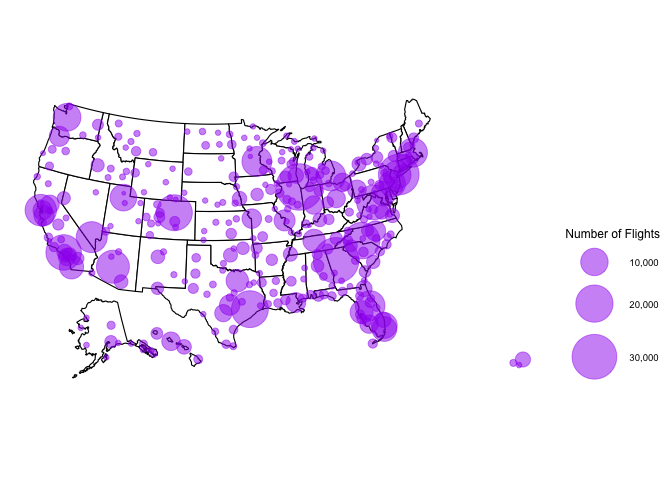

Number of Flights by City: Arrivals

We see a similar result for the flight destination cities. There isn’t any one state where the number of flights is less than 8. That, combined with the boxplot we looked at earlier, suggests that there may not be an outlier/anomaly in terms of an origin/destination of a flight. We will have to study this further, but we will move on for now.

We can now take a look at the relationship between departure and arrival delays. We would expect this relationship to be roughly linear, since if a flight departs 10 minutes late, it is likely to arrive 10 minutes late as well. However, there are conditions under which this will not be true. E.g., good weather will allow for a shorter flight, while bad weather can delay it; sometimes planes have to wait on the tarmac for their spot to open up even after the plane landed; any other unexpected situations.

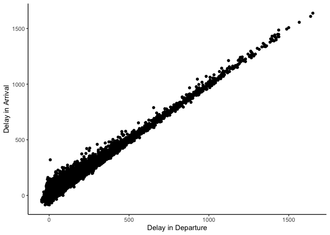

Departure vs Arrival Delays

While 18,022 observations are not included in this plot (these are missing observations and they make up about 3.1% of the observations), it is still abundantly clear that the relationship between the delay in flight departure and arrival is practically linear. There are, however some interesting patterns worth mentioning.

While majority of the data are concentrated near the left bottom corner (low values), there are quite a few observations exceeding these small delays, even going into over a day delay (1,651 minutes = 27 hours and 31 minutes). It is plausible that some flights did indeed get delayed for over a day in a few cases, especially given that it’s January and a lot of the flights originated at/arrived to the east coast, where the weather conditions could be quite poor.

Further notice that in our earlier analyses, we saw that 3rd quartile for departure delays was 5 minutes and for arrival delays, it was 7 minutes. Thus, it is suggestive that the long delays are potentially outliers that can be explained by some other factors and not anomalies (as we see a lot of these).

Another interesting observation is that the arrival delays sometimes exceed departure delays (e.g., 231 minutes vs. 89 minutes). As we mentioned earlier, there are explainable reasons for why that may happen, so these values are conceivable. Also note that a lot of the values for both variables are negative, suggesting that the flights departed/arrived earlier than the scheduled time.

We can further analyse the departure and arrival delays, as compared to the day of the week.

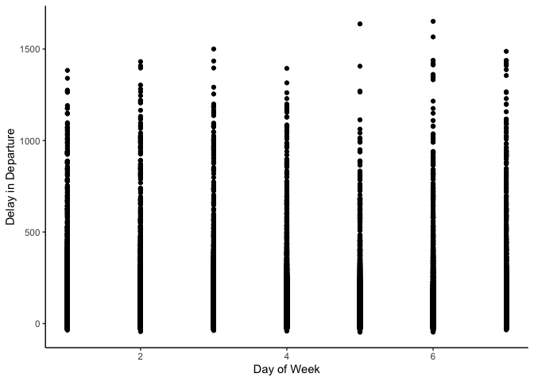

Departure Delays by Day of the Week

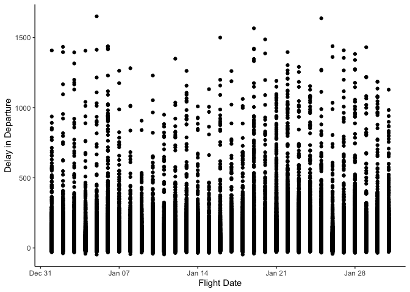

Departure Delays by Date

Similar to the finding for the days of the week, we see that there are a few extreme observations that fall on specific dates. Namely, there are two observations that really stand out - the extreme delay on the 5th and the 25th - these are relatively extreme to the rest of the data. While these are the most “extreme” relative to the data, it does not mean that the other numbers we are seeing are not extreme - delays of over a few hours are questionable regardless of the day of the week/time if the month.

These results will be very similar for the delay in arrivals, so those are not presented again.

Another variable that’s worth analyzing to better understand the long delays is **arr_del15**. We suspect that this is an indicator variable equaling 1 when a flight is delayed for over 15 minutes or 0 otherwise.

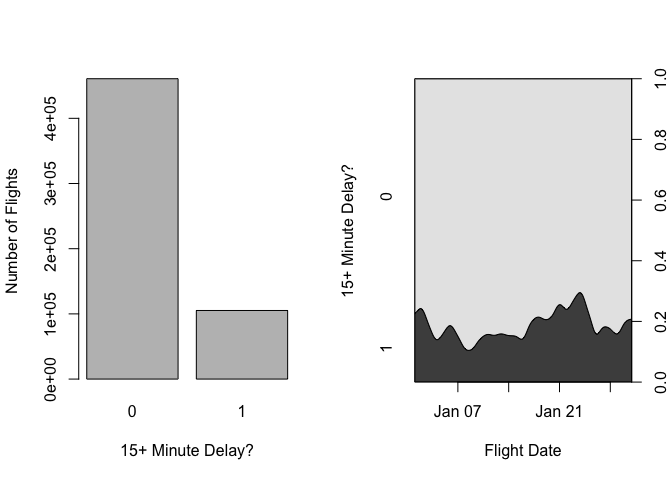

15+ Minute Arrival Delays Exploration

We see that only a relatively small fraction of flights was delayed for over 15 minutes (only ~18% of all flights, which matches with the data on arrival delays). We can take a look at how these delays are spread out throughout the month of January. Also above we see that there are not any obvious extreme discrepancies in the delay patterns - the fraction of flights that arrive over 15 minutes late hovers around the average for every day if the month.

We also want to consider arrival delay of less than -15 minutes, i.e., those flights that arrived over 15 minutes early.

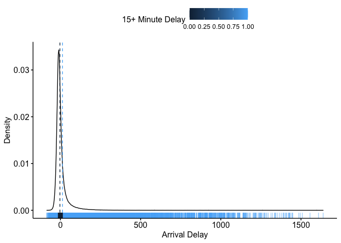

15+ Minute Arrival Delays vs Arrival Delays

```r
summary(flights$ARR_DELAY[which(flights$ARR_DEL15==1)])
```

[output not shown]

## Data Analysis: Departure vs Arrival Delays

### HDBSCAN

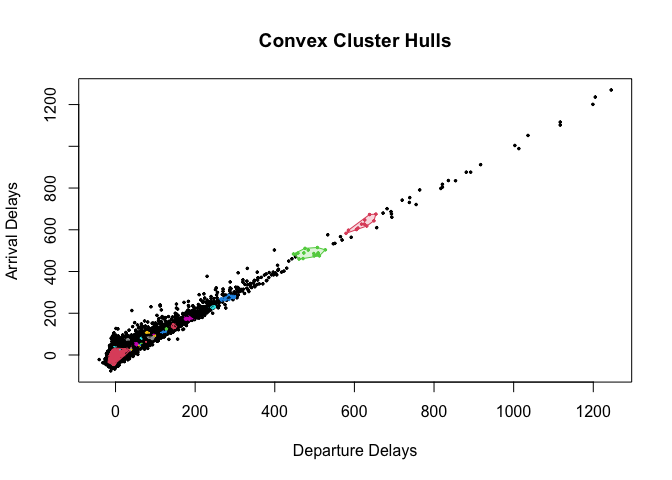

Clusters for Full Data (Sample)

Above is the plot for the results of HDBSCAN for the entire dataset. The black points are the outliers (as identified by the method). Note that here we only used a sample from the data due to the dataset dimensions - there are far too many observations for the package to run, so we will need to come up with a method to sample over the data and observe what’s identified as an “outlier”.

```r
n <- 100
z <- indz <- vector(mode="list", length=n)
hdbscanResult <- vector(mode="list", length=n)
for (i in 1:n){
  z[[i]] <- numvars[sample(nrow(numvars),20000),]
  hdbscanResult[[i]] <- which(hdbscan(z[[i]],minPts=10)$cluster==0)
  indz[[i]] <- as.numeric(rownames(z[[i]][hdbscanResult[[i]],]))
}

indH <- unlist(indz)
```

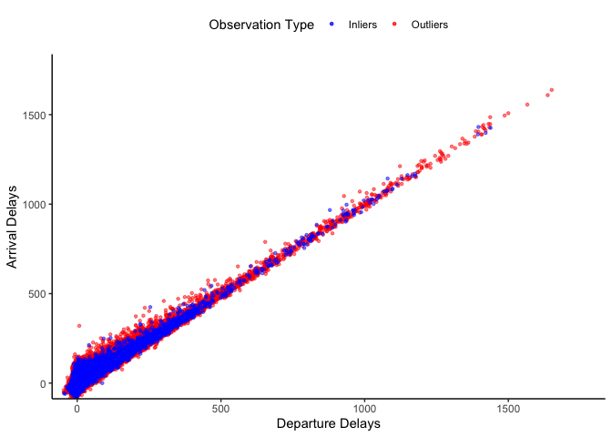

HDBSCAN: Clusters for Full Data

```r
colors <- c("Inliers" = "blue", "Outliers" = "red")
ggplot() +
  labs(x = "Departure Delays", y = "Arrival Delays") +
  theme_classic() +
  geom_point(data=flights[unique(indH[duplicated(indH)]),],
             aes(x=DEP_DELAY,y=ARR_DELAY,color="red"),
             alpha=0.5,shape=20) +
  geom_point(data=flights[-unique(indH[duplicated(indH)]),],
             aes(x=DEP_DELAY,y=ARR_DELAY,color="blue"),
             alpha=0.5,shape=20) +
  theme(legend.position = "top", legend.direction = "horizontal") +
  scale_color_identity(name = "Observation Type",
                          breaks = c("blue", "red"),
                          labels = c("Inliers", "Outliers"),
                          guide = "legend") +
  coord_cartesian(xlim = c(0, 1750), ylim = c(0, 1750))
```

### Mahalanobis Distance

We can use a distance based method to group those observations that are similar (as we did before, but only now we’ll focus on creating one group). A good start here would be mahalanobis - we will look for the distances between observations, select a reasonable cut off distance, and see how this compares to the previous results.

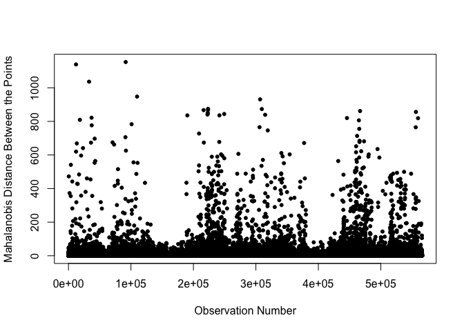

Mahalanobis Distance

It seems that the majority of the distances between points and the calculated data center are quite small - mostly below ~200. We can begin by selecting a cut-off distance equivalent to the 95th percentile. In this case, this is 6.13 and there are 28,6290 observations that are greater than the aforementioned value. We can plot these observations as outliers (in red) vs the rest of the data or inliers (in blue).

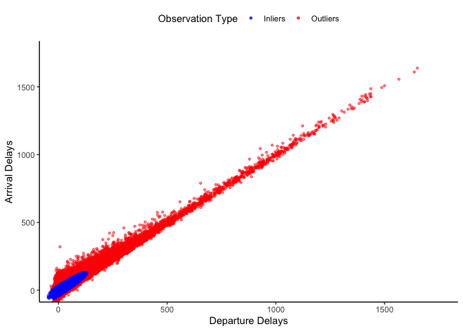

Mahalanobis Distance: 95th Percentile

This is quite similar to what we found previously (and what we expected to see) - those observations that have shorter delay times are considered inliers, while those exceeding a pre-specified threshold are outliers (or, potentialy, anomalies). It is also clear that those obsrvations where the delays in departures vs arrivals are not consistent (e.g., 3 vs 73 minutes) are thought of as outliers.

Next, we can try to increase this threshold and see how the pattern changes for the inliers. We now present a plot for the delay data where 97.5% of the data are inliers (based on the calculated distances) and so 14,149 observations are potential outliers.

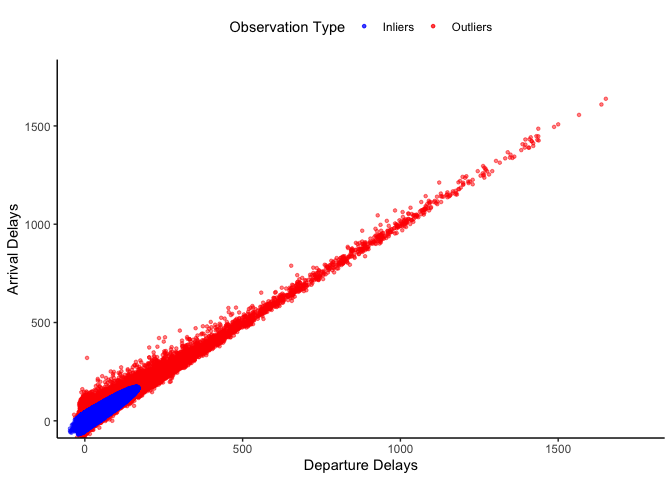

It becomes evident that whatever observations are close to the calculated center (9 minutes for departure and 4 minutes for arrival delays) will be regarded as the inliers. We conclude that it makes more sense to use the 95th percentile as a frame of reference (although the two percentiles give similar results).

### Cosine Similarity Distance

Next, we can use the cosine similarity distance and see how this compares to previous results. We do so by calculating the similarity between the data points and the data center - simply the means for each departure and arrival delays. We again plot the distances and see that the majority are concentrated around zero. We will again choose the 95th percentile as the distance cutoff and treat all values above this as outliers. There are 28,297 of these.

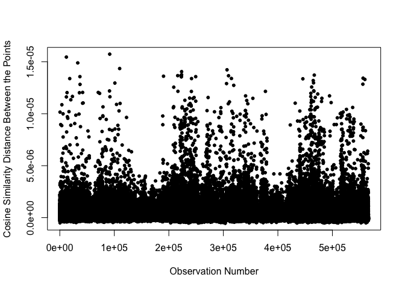

Cosine Similarity Distance

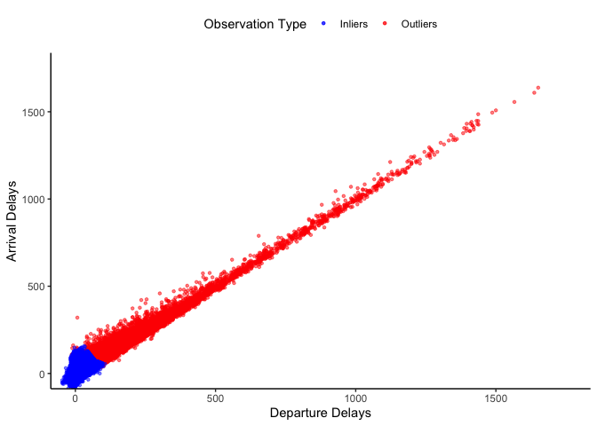

Cosine Similarity Distance: 95th Percentile

Again we see a similar pattern to that found when using the Mahalanobis distance. Note that out of roughly 28,290 identified outliers by both methods, 15,986 (or 56.4%) overlap - this gives us some confidence in there observations being true outliers. We will compare the results for all methods later and make conclusions about anamolous data points.

```r
length(intersect(which(d>as.numeric(quantile(d,0.95))),which(mdist>as.numeric(quantile(mdist,0.95)))))
```

```
## [1] 15986
```

### Isolation Forest Method

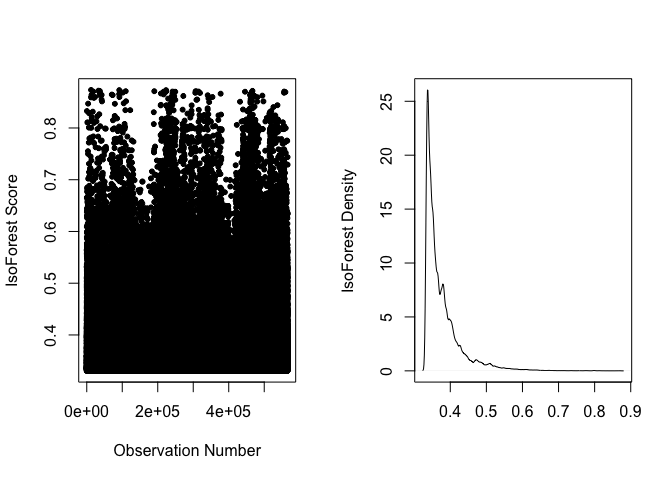

Isolation Forest Distance

We can proceed with creating 2,220 trees with various parameters, identifying the outliers for each, and then comparing these to each other. The result is the outliers that repeatedly show up in each tree.

```r
pars <- list("sample_size"=c(seq(256,565760,2560),565963),
             "ntrees"=seq(10,100,10))
iso.den <- matrix(rep(list(vector(mode="list")),length(pars[[1]])*length(pars[[2]])),
                  nrow=length(pars[[1]]),ncol=length(pars[[2]]))
for (i in 1:length(pars[[1]])){
  for (j in 1:length(pars[[2]])){
    iso.den[[i,j]] <- which(predict(isolation.forest(numvars,sample_size=pars[[1]][i],
                        ntrees=pars[[2]][j],ndim=1,nthreads=1),numvars)>
                        quantile(predict(isolation.forest(numvars,sample_size=pars[[1]][i],
                        ntrees=pars[[2]][j],ndim=1,nthreads=1),numvars),0.99))
  }
}
isoF <- unique(unlist(iso.den)[duplicated(unlist(iso.den))])
```

Below is the plot with the outlying and inlying observations. Once again, this is consistent with what we saw for the distance-based methods.

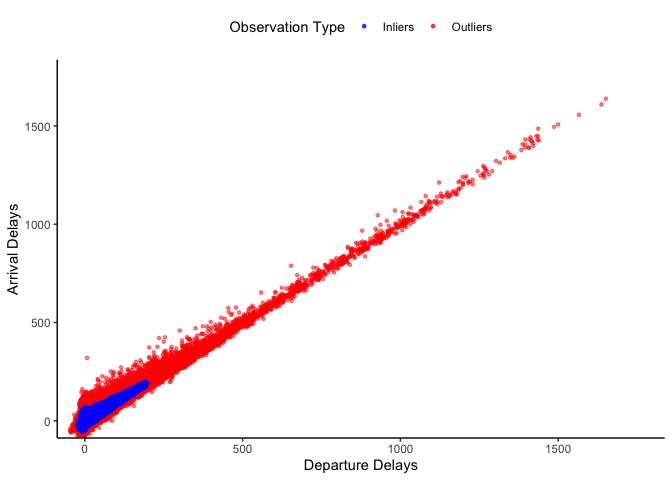

IsoForest: 99th Percentile

### Local Outlier Factor

```r
manh.dist <- function(x,y){
  d <- matrix(nrow=length(x),ncol=length(y))
  for (i in 1:(length(x))){
    for (j in 1:length(y)){
      d[i,j] <- abs(x[i]-x[j])+abs(y[i]-y[j])
    }
  }
  d
}
methodLOF <- function(number){
  s <- sample(nrow(numvars),number)
  mat <- numvars[s,]
  mat <- scale(mat,center=TRUE,scale=TRUE)
  k <- floor(sqrt(dim(mat)[1]))
  mdist <- manh.dist(mat[,1],mat[,2])
  kdist <- t(apply(mdist,1,order))[,seq(2,1+k,1)]

  rd <- matrix(nrow=dim(kdist)[1],ncol=dim(kdist)[2])
  for (i in 1:(dim(kdist)[1])){
    for (j in 1:(dim(kdist)[2])){
     rd[i,j] <- max(mdist[i,kdist[i,j]],mdist[kdist[i,j],kdist[kdist[i,j],k]])
   }
  }
  lrd <- c()
  for (i in 1:dim(kdist)[1]){
    lrd[i] <- k/sum(rd[i,])
  }

  lof <- c()
  for (i in 1:dim(kdist)[1]){
    lof[i] <- sum(lrd[kdist[i,]])/(k*lrd[i])
  }

  as.numeric(s[which(lof>quantile(lof,0.99))])
}
lofs <- replicate(500,methodLOF(5000))
lofs <- unlist(lofs)[duplicated(unlist(lofs))]
```

Below is the plot of inliers vs outliers.

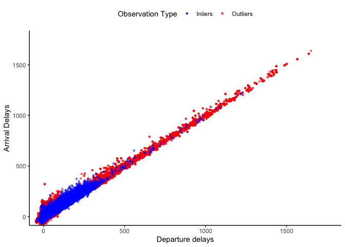

LOF: 99th Percentile

## Final Results

We can compare the results of all methods. We won’t display each outlier as there are too many here; instead, we will display how many outliers each method identified.

Outliers for Each Method

[output not shown]

```
## [1] 91664

##     Arrival Delays Departure Delays
## min            -49              -21
## max             86               88
```

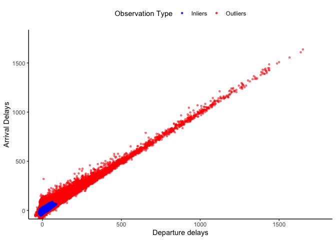

Outliers for Flight’s Data